# HW2: Data Import, Cleaning, and Exploration

Author

Hangyu Li

Published

October 8, 2026

## Overview

📄 Download this assignment as a Quarto file (HW2.qmd): open it in Positron and click **Preview** to get a standalone HTML copy you can read offline.

In this assignment you will work with the **PalmTraits 1.0 dataset**, a global database of functional traits for more than 2,500 palm species. It is real data, so it needs cleaning before it can be analyzed. You will import it, clean it with base R, summarize it (including one `dplyr` summary), and explore it with plots.

**Everything is done in Positron, in a single Quarto document.** You submit that `.qmd` file and its rendered HTML.

The required parts are **guided**: each step tells you which functions to use and what to look for. The Optional Extensions at the end are not graded. They are good practice for HW3 and the midterm, and we can go over them in the Wednesday session.

**ImportantAI policy and where AI would fail here**

AI tools are **not permitted** on this homework (see the syllabus AI Policy): the point is to build the coding fluency you need for the midterm, where no AI is available. No tool is required, and no one is advantaged by paying for one. Where AI would fail here: it may hallucinate PalmTraits column names or coding conventions, write cleaning code that silently drops or recodes rows incorrectly, and give confident but wrong descriptions of the data. Only the dataset documentation and your own checks (`str()`, `summary()`, row counts) can tell you what is true.

**Homework check:** I may ask you to briefly explain one of your solutions in the Wednesday section (random sample, about 5 minutes). Be ready to walk through your own code and reasoning.

## Learning Objectives

By completing this assignment, you will be able to:

- Set up a reproducible project in Positron and write your analysis as a Quarto document
- Import a tab-delimited text file into R and inspect it
- Find and handle missing values, fix data types, and create new variables with base R
- Calculate descriptive statistics and frequency tables, and interpret them in context
- Create and interpret histograms, boxplots, and scatterplots

## About the Dataset

The PalmTraits 1.0 database contains functional trait data for palm species (family Arecaceae). It captures traits related to:

- Growth forms (climbing, erect, acaulescent = stemless)
- Stem characteristics (height, diameter, armature/spines)
- Leaf characteristics (blade length, number of leaves)
- Fruit characteristics (length, width, color, shape)

For the growth-form and armature variables, `0` = absent, `1` = present, and `2` = both states occur in the species.

**Citation:** Kissling, W.D., Balslev, H., Baker, W.J., Dransfield, J., Göldel, B., Lim, J.Y., Onstein, R.E., & Svenning, J.-C. (2019). PalmTraits 1.0, a species-level functional trait database of palms worldwide. Scientific Data, 6, 178. https://www.nature.com/articles/s41597-019-0189-0

## Part 0: Set Up Your Project in Positron (5 points)

### 0.1 Create a project folder

1. In Positron, choose **File → Open Folder…** and create/open a new folder called `STAT204-HW2` (you can put it inside the Git repository you set up in Week 1).
2. In the **Explorer** pane (left sidebar), create a subfolder called `data`.

Opening the folder matters: Positron’s console and Quarto both use it as the **working directory**, so relative paths like `data/...` just work. **Do not use `setwd()`** in your document.

### 0.2 Download the dataset

1. Go to: https://datadryad.org/stash/dataset/doi:10.5061/dryad.ts45225
2. Click “Download Dataset” (free and open access) and extract the files.
3. Find `PalmTraits_1.0.txt` (a tab-delimited text file, under the Sep 09, 2020 tab) and move it into your `data/` folder.

### 0.3 Create your Quarto document

1. Choose **File → New File… → Quarto Document**, and save it in the project folder (not in `data/`) as `LastName_FirstName_HW2.qmd`.
2. Check the **interpreter picker** in the top-right corner of Positron: it should show an **R** session. If it shows Python, click it and select R.
3. Replace the default header with:

```yaml
---
title: "HW2: Data Import, Cleaning, and Exploration"
author: "Your Name"
date: today
format:
  html:
    toc: true
    embed-resources: true
---
```

4. Add a short paragraph saying where the data comes from (the Dryad link and the file name), then this setup chunk:

**Answer:** I downloaded the `PalmTraits_1.0.txt` data from https://datadryad.org/stash/dataset/doi:10.5061/dryad.ts45225.

```r
library(dplyr)   # used in Part 3.3 only
```

**Working in Positron:**

- Run the current line or selection with **Ctrl/Cmd + Enter**, or a whole chunk with **Run Cell** above it.
- The **Variables** pane shows every object you create. Click the table icon next to a data frame (or run `View(palm_data)` in the console) to open it in the **Data Explorer**.
- **Preview** your document often (the Preview button, or **Ctrl/Cmd + Shift + K**). If it renders, your code runs from top to bottom in a fresh session, which is what “reproducible” means.
- Optional: commit your work to Git from the **Source Control** pane as you go, like you practiced in Week 1.

**Points:** the document renders without errors, uses a relative path for the data, and has a setup chunk.

## Part 1: Import and First Look (15 points)

### 1.1 Import the data (8 points)

```r
palm_data <- read.delim("data/PalmTraits_1.0.txt",
                        header = TRUE,
                        stringsAsFactors = FALSE)

dim(palm_data)
```

```
[1] 2557   29
```

```r
names(palm_data)
```

```
 [1] "SpecName"              "accGenus"              "accSpecies"
 [4] "PalmTribe"             "PalmSubfamily"         "Climbing"
 [7] "Acaulescent"           "Erect"                 "StemSolitary"
[10] "StemArmed"             "LeavesArmed"           "MaxStemHeight_m"
[13] "MaxStemDia_cm"         "UnderstoreyCanopy"     "MaxLeafNumber"
[16] "Max_Blade_Length_m"    "Max_Rachis_Length_m"   "Max_Petiole_length_m"
[19] "AverageFruitLength_cm" "MinFruitLength_cm"     "MaxFruitLength_cm"
[22] "AverageFruitWidth_cm"  "MinFruitWidth_cm"      "MaxFruitWidth_cm"
[25] "FruitSizeCategorical"  "FruitShape"            "FruitColorDescription"
[28] "MainFruitColors"       "Conspicuousness"
```

```r
head(palm_data, 5)
```

```
                  SpecName       accGenus accSpecies     PalmTribe
1   Acanthophoenix crinita Acanthophoenix    crinita       Areceae
2 Acanthophoenix rousselii Acanthophoenix  rousselii       Areceae
3     Acanthophoenix rubra Acanthophoenix      rubra       Areceae
4   Acoelorrhaphe wrightii  Acoelorrhaphe   wrightii Trachycarpeae
5       Acrocomia aculeata      Acrocomia   aculeata      Cocoseae
  PalmSubfamily Climbing Acaulescent Erect StemSolitary StemArmed LeavesArmed
1    Arecoideae        0           0     1            1         1           1
2    Arecoideae        0           0     1            1         1           1
3    Arecoideae        0           0     1            1         1           1
4  Coryphoideae        0           0     1            0         0           1
5    Arecoideae        0           0     1            1         1           1
  MaxStemHeight_m MaxStemDia_cm UnderstoreyCanopy MaxLeafNumber
1            10.0            20            canopy            15
2            25.0            30            canopy            NA
```

[output cut: 27 more lines]

```r
str(palm_data)
```

```
'data.frame':   2557 obs. of  29 variables:
 $ SpecName             : chr  "Acanthophoenix crinita" "Acanthophoenix rousselii" "Acanthophoenix rubra" "Acoelorrhaphe wrightii" ...
 $ accGenus             : chr  "Acanthophoenix" "Acanthophoenix" "Acanthophoenix" "Acoelorrhaphe" ...
 $ accSpecies           : chr  "crinita" "rousselii" "rubra" "wrightii" ...
 $ PalmTribe            : chr  "Areceae" "Areceae" "Areceae" "Trachycarpeae" ...
 $ PalmSubfamily        : chr  "Arecoideae" "Arecoideae" "Arecoideae" "Coryphoideae" ...
 $ Climbing             : int  0 0 0 0 0 0 0 0 0 0 ...
 $ Acaulescent          : int  0 0 0 0 0 0 1 0 1 0 ...
 $ Erect                : int  1 1 1 1 1 1 0 1 0 1 ...
 $ StemSolitary         : int  1 1 1 0 1 1 1 1 1 1 ...
 $ StemArmed            : int  1 1 1 0 1 1 1 1 1 1 ...
 $ LeavesArmed          : int  1 1 1 1 1 1 1 1 1 1 ...
 $ MaxStemHeight_m      : num  10 25 15 9.1 12 18 0 NA 0 NA ...
 $ MaxStemDia_cm        : num  20 30 18 15 50 35 NA NA NA NA ...
 $ UnderstoreyCanopy    : chr  "canopy" "canopy" "canopy" "canopy" ...
 $ MaxLeafNumber        : int  15 NA 20 25 30 15 NA NA 6 NA ...
 $ Max_Blade_Length_m   : num  2.3 3 3.1 1.3 3.5 3 NA NA 0.9 NA ...
 $ Max_Rachis_Length_m  : num  NA NA 3 0.7 2.5 NA NA NA 0.54 NA ...
 $ Max_Petiole_length_m : num  NA NA NA 0.65 NA 0.65 NA NA 0.51 NA ...
 $ AverageFruitLength_cm: num  0.65 2 1 0.7 4.25 2.5 2 NA 2.25 4.6 ...
 $ MinFruitLength_cm    : num  0.6 NA NA NA 3.5 NA NA NA 1.5 3.8 ...
 $ MaxFruitLength_cm    : num  0.7 NA NA NA 5 NA NA NA 3 5.4 ...
 $ AverageFruitWidth_cm : num  0.5 0.8 0.7 0.7 4.6 1.8 2 NA 2.25 4.6 ...
 $ MinFruitWidth_cm     : num  NA NA NA 0.5 3.8 NA NA NA 1.5 3.8 ...
 $ MaxFruitWidth_cm     : num  NA NA NA 0.9 5.4 NA NA NA 3 5.4 ...
 $ FruitSizeCategorical : chr  "small" "small" "small" "small" ...
 $ FruitShape           : chr  "" "ovoid" "ovoid" "ovoid" ...
 $ FruitColorDescription: chr  "black" "black" "black" "orange-brown; becomming black" ...
 $ MainFruitColors      : chr  "black" "black" "black" "brown; black" ...
 $ Conspicuousness      : chr  "cryptic" "cryptic" "cryptic" "cryptic" ...
```

**Instructions:**

- Import the file with `read.delim()` (it is tab-delimited, which is the default for `read.delim()`)
- Show `dim(palm_data)`, `names(palm_data)`, and `head(palm_data, 5)`
- Show `str(palm_data)`
- In one or two sentences: how many species and variables are there? Which variables did R read as numbers, and which as text?

**Answer:** There are 2557 species and 29 variables.

`Climbing`, `Acaulescent`, `Erect`, `StemSolitary`, `StemArmed`, `LeavesArmed`, `MaxStemHeight_m` `MaxStemDia_cm` `MaxLeafNumber`, `Max_Blade_Length_m`, `Max_Rachis_Length_m`, `Max_Petiole_length_m`, `AverageFruitLength_cm`, `MinFruitLength_cm`, `MaxFruitLength_cm` , `AverageFruitWidth_cm`, `MinFruitWidth_cm` and `MaxFruitWidth_cm` are read as numbers.

`SpecName`, `accGenus`, `accSpecies`, `PalmTribe`, `PalmSubfamily`, `UnderstoreyCanopy`, `FruitSizeCategorical`, `FruitShape` `FruitColorDescription` `MainFruitColors` and `Conspicuousness` are read as text.

### 1.2 Guided exploration in the Data Explorer (7 points)

Open `palm_data` in Positron’s **Data Explorer** (Variables pane → table icon). Use the column headers to sort and the filter bar to filter. The summary panel on the left shows the percentage of missing values for each column.

Answer these in your document, in text:

1. Sort by `MaxStemHeight_m` from largest to smallest. Which species is the tallest, and what is its growth form (look at `Climbing`)? Does a “height” of that size make sense for that growth form?

**Answer:** Calamus manan is the tallest and it has a climbing growth form. Yes, because it needs to climb or else it’s hard for Calamus manan to vertically grow to 170m.

2. Filter to `Climbing` equal to 1. How many climbing species are there?

**Answer:** There are 530 climbing species.

3. Which of these columns has the most missing values: `MaxStemHeight_m`, `Max_Blade_Length_m`, `AverageFruitLength_cm`, `AverageFruitWidth_cm`?

**Answer:** `MaxStemHeight_m` has 446 missing values, `Max_Blade_Length_m` has 659 missing values `AverageFruitLength_cm` has 505 missing values and `AverageFruitWidth_cm` has 563 missing values. So `Max_Blade_Length_m` has the most missing values.

4. Look at the `UnderstoreyCanopy` column. Besides `understorey` and `canopy`, what other values appear? Is anything missing that R would **not** count as `NA`?

**Answer:** There are also empty strings `""` and `both` besides `understorey` and `canopy`. The empty strings `""` are not counted as `NA`.

Then confirm (a) and (b) with code, so the answers appear in your rendered document:

```r
palm_data$SpecName[which.max(palm_data$MaxStemHeight_m)]
```

```
[1] "Calamus manan"
```

```r
sum(palm_data$Climbing == 1)
```

```
[1] 530
```

```r
table(palm_data$UnderstoreyCanopy)
```

```
                   both      canopy understorey
        265          14        1334         944
```

## Part 2: Data Cleaning with Base R (35 points)

### 2.1 Find the missing values (8 points)

```r
# Missing values in the whole dataset, and per column
sum(is.na(palm_data))
```

```
[1] 13359
```

```r
colSums(is.na(palm_data))
```

```
             SpecName              accGenus            accSpecies
                    0                     0                     0
            PalmTribe         PalmSubfamily              Climbing
                    0                     0                     0
          Acaulescent                 Erect          StemSolitary
                    0                     0                   375
            StemArmed           LeavesArmed       MaxStemHeight_m
                   55                   120                   446
        MaxStemDia_cm     UnderstoreyCanopy         MaxLeafNumber
                  602                     0                  1251
   Max_Blade_Length_m   Max_Rachis_Length_m  Max_Petiole_length_m
                  659                  1026                  1347
AverageFruitLength_cm     MinFruitLength_cm     MaxFruitLength_cm
                  505                  1651                  1641
 AverageFruitWidth_cm      MinFruitWidth_cm      MaxFruitWidth_cm
                  563                  1563                  1555
 FruitSizeCategorical            FruitShape FruitColorDescription
                    0                     0                     0
      MainFruitColors       Conspicuousness
                    0                     0
```

```r
# Percentage missing per column, sorted
pct_missing <- round(100 * colMeans(is.na(palm_data)), 1)
sort(pct_missing, decreasing = TRUE)
```

```
    MinFruitLength_cm     MaxFruitLength_cm      MinFruitWidth_cm
                 64.6                  64.2                  61.1
     MaxFruitWidth_cm  Max_Petiole_length_m         MaxLeafNumber
                 60.8                  52.7                  48.9
  Max_Rachis_Length_m    Max_Blade_Length_m         MaxStemDia_cm
                 40.1                  25.8                  23.5
 AverageFruitWidth_cm AverageFruitLength_cm       MaxStemHeight_m
                 22.0                  19.7                  17.4
         StemSolitary           LeavesArmed             StemArmed
                 14.7                   4.7                   2.2
             SpecName              accGenus            accSpecies
                  0.0                   0.0                   0.0
            PalmTribe         PalmSubfamily              Climbing
                  0.0                   0.0                   0.0
          Acaulescent                 Erect     UnderstoreyCanopy
                  0.0                   0.0                   0.0
 FruitSizeCategorical            FruitShape FruitColorDescription
                  0.0                   0.0                   0.0
      MainFruitColors       Conspicuousness
                  0.0                   0.0
```

```r
# Duplicated rows
sum(duplicated(palm_data))
```

```
[1] 0
```

**Instructions:** run the code above, then write two or three sentences: which kinds of traits (stem, leaf, fruit) have the most missing data, and are there duplicated rows?

**Answer:** Fruits have the most missing data since the fruit length and width data have over 60% of missing value.

### 2.2 Create a working subset (5 points)

Keep only these columns:

```r
keep <- c("SpecName", "Climbing", "Acaulescent", "Erect", "StemArmed",
          "MaxStemHeight_m", "Max_Blade_Length_m",
          "AverageFruitLength_cm", "AverageFruitWidth_cm")
palm_subset <- palm_data[, keep]
dim(palm_subset)
```

```
[1] 2557    9
```

Report how many variables and observations your subset has.

**Answer:** Now we have 9 variables with 2557 observations.

### 2.3 Handle missing values (8 points)

We will keep the species that have **both** a stem height and a fruit length, since Parts 3 and 4 use those two variables the most:

```r
key_vars <- c("MaxStemHeight_m", "AverageFruitLength_cm")
palm_clean <- palm_subset[complete.cases(palm_subset[, key_vars]), ]
nrow(palm_subset) - nrow(palm_clean)   # how many rows were removed?
```

```
[1] 650
```

```r
(nrow(palm_subset) - nrow(palm_clean))/nrow(palm_subset)   # what is the percentage of the removed data
```

```
[1] 0.2542041
```

```r
colSums(is.na(palm_clean))   # what is still missing?
```

```
             SpecName              Climbing           Acaulescent
                    0                     0                     0
                Erect             StemArmed       MaxStemHeight_m
                    0                    17                     0
   Max_Blade_Length_m AverageFruitLength_cm  AverageFruitWidth_cm
                  199                     0                    54
```

**Instructions:** run the code and answer in two or three sentences:

- How many species did you remove, and what percentage of the data is that?
- Which variables still have missing values? (That’s fine: use `na.rm = TRUE` when you summarize them.)
- Could removing these species bias the results? Think about which kinds of palms are more likely to be missing measurements.

**Answer:** 650 species are removed and it’s 25.42% of the original data.

`StemArmed`, `Max_Blade_Length_m` and `AverageFruitWidth_cm` still have missing values.

Removing these species would bias the results because palms with no visible stems or fruits may be more likely to lack measurements and therefore be excluded.

### 2.4 Fix data types (6 points)

`StemArmed` is stored as a number, but it is really a category. Convert it to a factor with readable labels, and check the result:

```r
str(palm_clean$StemArmed)
```

```
 int [1:1907] 1 1 1 0 1 1 1 1 0 0 ...
```

```r
palm_clean$StemArmed <- factor(palm_clean$StemArmed,
                               levels = c(0, 1),
                               labels = c("Unarmed", "Armed"))
table(palm_clean$StemArmed, useNA = "ifany")
```

```
Unarmed   Armed    <NA>
   1705     185      17
```

**Instructions:** do the same for `Climbing`, using `levels = c(0, 1, 2)` and `labels = c("No", "Yes", "Both")`. Show `str(palm_clean)` after your conversions, and explain in one or two sentences why it matters that these variables are factors rather than numbers (think about what `mean()` or `summary()` would give you).

**Answer:**

```r
palm_clean$Climbing <- factor(palm_clean$Climbing,
                               levels = c(0, 1, 2),
                               labels = c("No", "Yes", "Both"))
table(palm_clean$Climbing, useNA = "ifany")
```

```
  No  Yes Both
1583  310   14
```

```r
str(palm_clean)
```

```
'data.frame':   1907 obs. of  9 variables:
 $ SpecName             : chr  "Acanthophoenix crinita" "Acanthophoenix rousselii" "Acanthophoenix rubra" "Acoelorrhaphe wrightii" ...
 $ Climbing             : Factor w/ 3 levels "No","Yes","Both": 1 1 1 1 1 1 1 1 1 1 ...
 $ Acaulescent          : int  0 0 0 0 0 0 1 1 0 0 ...
 $ Erect                : int  1 1 1 1 1 1 0 0 1 1 ...
 $ StemArmed            : Factor w/ 2 levels "Unarmed","Armed": 2 2 2 1 2 2 2 2 1 1 ...
 $ MaxStemHeight_m      : num  10 25 15 9.1 12 18 0 0 9 9 ...
 $ Max_Blade_Length_m   : num  2.3 3 3.1 1.3 3.5 3 NA 0.9 2.35 1.2 ...
 $ AverageFruitLength_cm: num  0.65 2 1 0.7 4.25 2.5 2 2.25 2.6 3 ...
 $ AverageFruitWidth_cm : num  0.5 0.8 0.7 0.7 4.6 1.8 2 2.25 1.1 1.3 ...
```

Because after converting numbers into factors, it’s easier for us to partition the groups of data and better summarize and manage the whole dataset. Also, it would give us categorical counts instead of numerical summaries.

### 2.5 Create new variables (8 points)

1. **Size category** from stem height. Run this code and show the table:

```r
palm_clean$size_category <- ifelse(palm_clean$MaxStemHeight_m <= 5, "Small",
                            ifelse(palm_clean$MaxStemHeight_m <= 15, "Medium",
                            ifelse(palm_clean$MaxStemHeight_m <= 30, "Tall", "Very Tall")))
palm_clean$size_category <- factor(palm_clean$size_category,
                                   levels = c("Small", "Medium", "Tall", "Very Tall"))
table(palm_clean$size_category)
```

```
    Small    Medium      Tall Very Tall
      837       621       351        98
```

2. **Fruit aspect ratio**: create `fruit_ratio` = `AverageFruitLength_cm` / `AverageFruitWidth_cm`. Use `summary()` on it. What does a ratio above 1 mean about the shape of the fruit? How many values are `NA`, and why?

**Answer:**

```r
palm_clean$fruit_ratio <- palm_clean$AverageFruitLength_cm / palm_clean$AverageFruitWidth_cm
summary(palm_clean$fruit_ratio)
```

```
   Min. 1st Qu.  Median    Mean 3rd Qu.    Max.     NAs
 0.1385  1.0000  1.3333  1.4661  1.6667  6.7500      54
```

The ratio above 1 means the average length of the fruit is bigger than its average width. There are 54 `NAs` and it’s because there are still missing values in `AverageFruitWidth_cm` according to 2.3.

## Part 3: Descriptive Statistics (20 points)

### 3.1 Summary statistics (10 points)

For `MaxStemHeight_m` **and** `AverageFruitLength_cm`, calculate the mean, median, standard deviation, and the quartiles:

```r
func_summary <- function(col){
  x <- palm_clean[,col]
  return (data.frame(col = col, mean = mean(x), median = median(x),
  sd = sd(x), min = quantile(x, 0), Q1 = quantile(x, 0.25),
  Q2 = quantile(x, 0.5), Q3 = quantile(x, 0.75), max = quantile(x, 1)))
}

summary_MaxStemHeight <- func_summary('MaxStemHeight_m')
summary_AvgFruitLength <- func_summary('AverageFruitLength_cm')
summary_tbl <- rbind(summary_MaxStemHeight, summary_AvgFruitLength)
rownames(summary_tbl) <- NULL
print(summary_tbl)
```

```
                    col      mean median        sd min   Q1  Q2   Q3 max
1       MaxStemHeight_m 11.202937    7.0 12.913217 0.0 3.00 7.0 15.0 170
2 AverageFruitLength_cm  2.195507    1.5  2.275187 0.4 1.05 1.5  2.5  45
```

Organize the results in a small data frame with one row per variable and one column per statistic, and print it.

**Interpret:** For each variable, compare the mean and the median. What does the difference tell you about the shape of the distribution?

**Answer:** For both `MaxStemHeight_m` and `AverageFruitLength_cm`, the mean is larger than its median. It suggests the distribution of them are right-skewed.

### 3.2 Frequency tables (5 points)

```r
table(palm_clean$size_category)
```

```
    Small    Medium      Tall Very Tall
      837       621       351        98
```

```r
prop.table(table(palm_clean$size_category))
```

```
     Small     Medium       Tall  Very Tall
0.43890928 0.32564237 0.18405873 0.05138962
```

```r
# Two-way table: size category vs armature, with row proportions
tab <- table(palm_clean$size_category, palm_clean$StemArmed)
tab
```

```
            Unarmed Armed
  Small         764    64
  Medium        537    77
  Tall          316    34
  Very Tall      88    10
```

```r
round(prop.table(tab, margin = 1), 2)
```

```
            Unarmed Armed
  Small        0.92  0.08
  Medium       0.87  0.13
  Tall         0.90  0.10
  Very Tall    0.90  0.10
```

**Interpret:** Which size category has the highest proportion of armed (spiny) palms? Write one sentence.

**Answer:** Category of medium size has the highest proportion 0.13.

### 3.3 Group summaries with `dplyr` (5 points)

`group_by()` splits the data into groups, and `summarize()` calculates statistics for each group. The pipe `%>%` (read it as “then”) passes the result of one step to the next:

```r
palm_clean %>%                       # start with the clean data, THEN
  group_by(StemArmed) %>%            # group it by armature, THEN
  summarize(
    n = n(),                                             # species per group
    mean_height = mean(MaxStemHeight_m),
    sd_height = sd(MaxStemHeight_m),
    median_fruit = median(AverageFruitLength_cm)
  )
```

```
# A tibble: 3 × 5
  StemArmed     n mean_height sd_height median_fruit
  <fct>     <int>       <dbl>     <dbl>        <dbl>
1 Unarmed    1705       11.2      13.1          1.5
2 Armed       185       12.0      11.5          1.65
3 <NA>         17        6.59      5.84         2.5
```

**Instructions:** run this summary, then change it to group by `size_category` and add **one more statistic** of your choice (for example `max()` of stem height, or the median of `Max_Blade_Length_m` with `na.rm = TRUE`). Store the result as `palm_summary` and print it. (If you see an `NA` group, those are species whose armature is unknown.) Write one or two sentences about what it shows.

```r
palm_summary <- palm_clean |>
  group_by(size_category) |>
  summarize(
    n = n(),
    mean_height = mean(MaxStemHeight_m),
    sd_height = sd(MaxStemHeight_m),
    median_fruit = median(AverageFruitLength_cm),
    max_stem = max(MaxStemHeight_m)
  )
palm_summary
```

```
# A tibble: 4 × 6
  size_category     n mean_height sd_height median_fruit max_stem
  <fct>         <int>       <dbl>     <dbl>        <dbl>    <dbl>
1 Small           837        2.38      1.61         1.3         5
2 Medium          621       10.4       3.24         1.7        15
3 Tall            351       23.0       4.36         1.8        30
4 Very Tall        98       49.4      21.6          1.88      170
```

Category of small size is the most common group, while very tall palms are the least common. mean, standard deviation and max of the stem height and median fruit length increases as the category of size increased.

## Part 4: Visualizations with Base R (15 points)

For each plot, add a title and axis labels with units, and write **one or two sentences** interpreting it.

### 4.1 Histogram of stem height (5 points)

Use `hist()` on `MaxStemHeight_m`. Describe the shape. Then make a second histogram of `log10(MaxStemHeight_m + 1)` and compare. (Why `+ 1`? Look for zeros in the data.)

**Answer:**

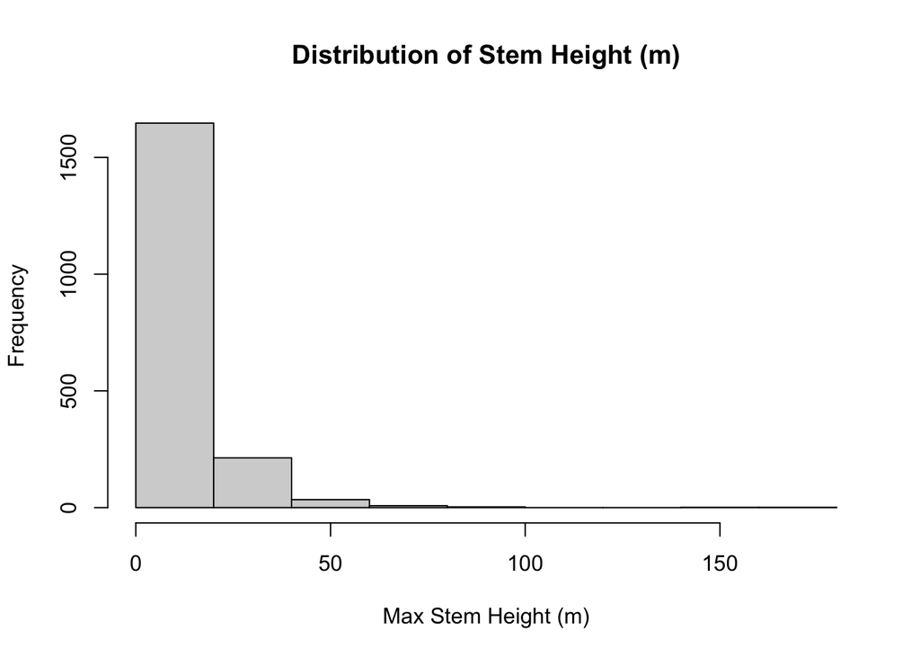

```r
hist(palm_clean$MaxStemHeight_m,
     main = 'Distribution of Stem Height (m)',
     xlab = 'Max Stem Height (m)')
```

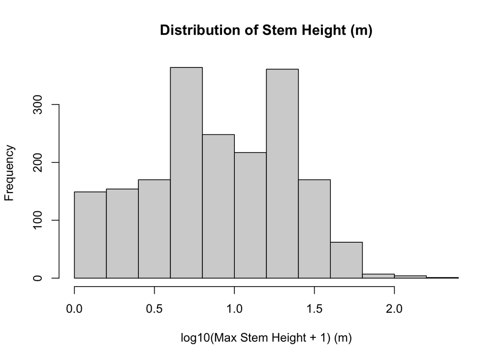

```r
hist(log10(palm_clean$MaxStemHeight_m + 1),
    main = 'Distribution of Stem Height (m)',
    xlab = 'log10(Max Stem Height + 1) (m)')
```

For the first histogram, it’s right-skewed and has a long right tail. And for the histogram after log-transformation, the distribution is flatter and less skewed.

### 4.2 Boxplot of stem height by armature (5 points)

Use `boxplot(MaxStemHeight_m ~ StemArmed, data = palm_clean, ...)`. Are armed palms taller or shorter than unarmed palms, typically? Are there many outliers?

**Answer:**

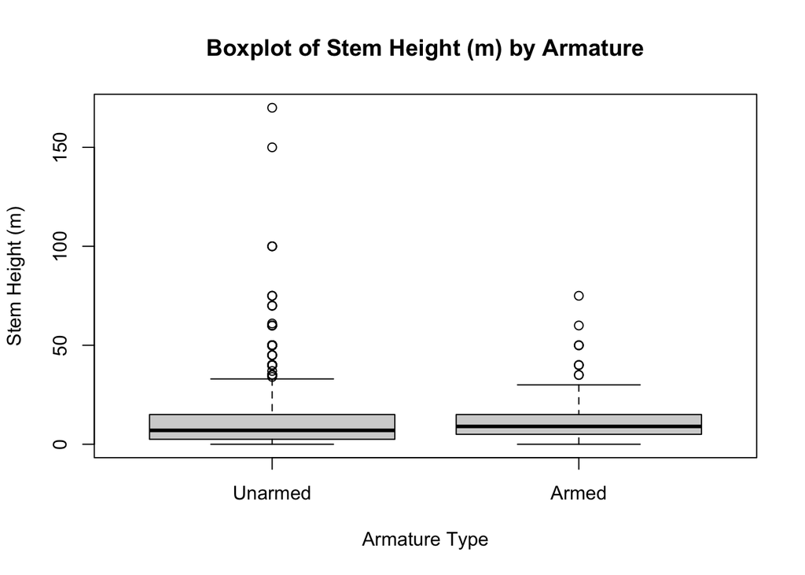

```r
boxplot(MaxStemHeight_m ~ StemArmed, data = palm_clean,
    main = 'Boxplot of Stem Height (m) by Armature',
    xlab = 'Armature Type',
    ylab = 'Stem Height (m)')
```

Typically there is not much difference of stem height between armed and unarmed palms and there are many outliers, especially for unarmed palms.

### 4.3 Scatterplot of fruit dimensions (5 points)

Plot `AverageFruitWidth_cm` (y) against `AverageFruitLength_cm` (x). Add the line `abline(0, 1)`, where length equals width. What does it mean for a species to be above or below that line? Use `cor(..., use = "complete.obs")` to report the correlation.

**Answer:**

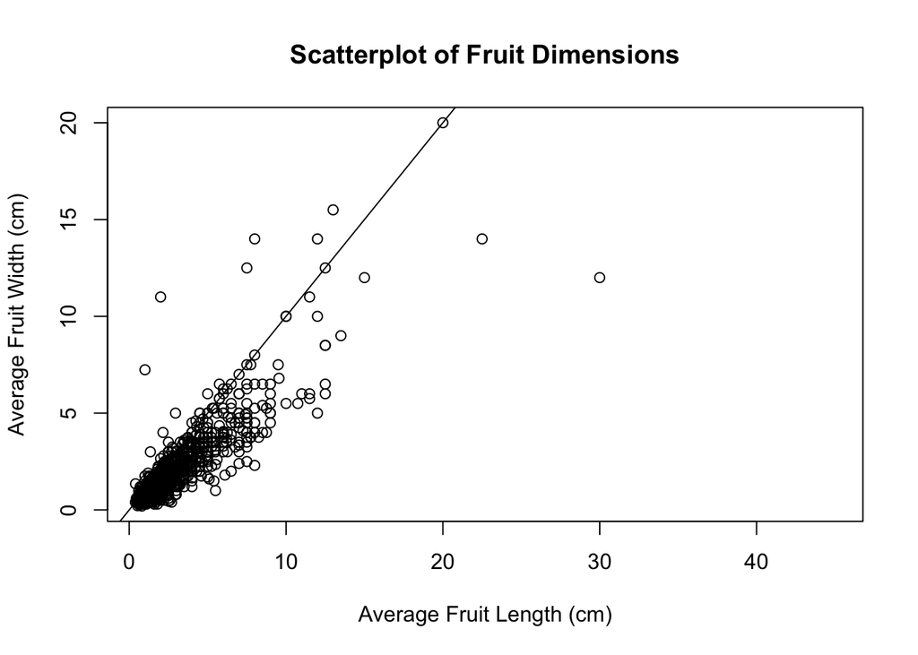

```r
plot(palm_clean$AverageFruitLength_cm, palm_clean$AverageFruitWidth_cm,
    main = 'Scatterplot of Fruit Dimensions',
    xlab = 'Average Fruit Length (cm)',
    ylab = 'Average Fruit Width (cm)')
abline(0,1)
```

```r
cor(palm_clean$AverageFruitLength_cm, palm_clean$AverageFruitWidth_cm, use = "complete.obs")
```

```
[1] 0.8781388
```

For dots that are above the line, it means the length of the fruit is smaller than the width of the fruit, and vice versa.

## Part 5: Reflection (10 points)

Write about **150 words** addressing:

1. **Cleaning decisions:** What was the biggest data quality issue you found, and how did your choices in Part 2 change the data you analyzed?
2. **Findings:** What are the two most interesting patterns you found about palm size, armature, or fruit shape?
3. **Workflow:** What was one thing that Positron’s Data Explorer or rendering your Quarto document helped you catch?

**Answer:** The biggest data quality issue is that there are a lot of missing values in the raw data especially for the min/max fruit length/width. In part 2, we manually selected 9 variables and we removed the data with NAs on `MaxStemHeight_m` and `AverageFruitLength_cm`. It helps to reduce the amount and portion of the missing values but may underrepresent those species with measurements that are hard to obtain.

One interesting pattern is most of the palm size is small and the summary table suggests a possible postive relation between the size and the median of the fruit length, with taller palms having larger median fruits length. The other one is most of the fruits have longer length than width.

The Positron’s Data Explorer helped me to notice empty strings in the `UnderstoreyCanopy` column which are hard to catch only by `is.na()`, showing why visually checking the data was useful.

## Optional Extensions

These are **not graded**. They are good practice for HW3 and the midterm. If you do them, put them in a section called “Optional” at the end of your document.

1. **Outliers.** For `MaxStemHeight_m`, compute Q1, Q3, and the IQR with `quantile()`, and flag values above Q3 + 1.5 × IQR. List the flagged species. Are they errors, or real extreme values? (Some palms, like *Ceroxylon quindiuense*, exceed 60 m, and climbing *Calamus* can exceed 100 m in length.) Decide whether to keep, remove, or flag them, and explain why.
2. **A primary growth form variable.** Combine `Climbing`, `Acaulescent`, and `Erect` into a single factor with levels “Climbing”, “Acaulescent”, “Erect”, and “Mixed”, using nested `ifelse()`. Make a frequency table, then redo the boxplot in 4.2 grouped by growth form.
3. **More pipes.** Use `%>%` to (a) keep only climbing palms, (b) select three columns and show the first 5 rows, and (c) compute the mean stem height.
4. **Grouping by two variables.** Repeat 3.3 with `group_by(size_category, StemArmed)`.
5. **Base R vs. dplyr.** Reproduce your `palm_summary` means with `tapply()` or `aggregate()`. Which approach do you find easier to read?
6. **Multi-panel figure.** Use `par(mfrow = c(2, 2))` to combine your plots and a `barplot()` of size-category frequencies into one figure.

## Submission Instructions

Submit to Canvas:

1. Your `LastName_FirstName_HW2.qmd` file
2. The rendered `LastName_FirstName_HW2.html` (with `embed-resources: true`, it is a single file that includes your plots)

You do **not** need to submit the data file. Your document must say where to download it and use the exact path `data/PalmTraits_1.0.txt`.

### Reproducibility checklist

Before you submit:

- ✅ The data is read with a **relative path**: `read.delim("data/PalmTraits_1.0.txt")`, not `"C:/Users/..."`, and there is no `setwd()`.
- ✅ All packages are loaded in the setup chunk (only `dplyr` is needed).
- ✅ Restart R (the restart button at the top of the Console pane), then **Preview** again. If it renders from a fresh session, it will render on my computer too.
- ✅ Every chunk has a descriptive label (`#| label: import-data`), and your code has comments.
- ✅ Your written answers are in the text of the document, not only in code comments.

## Grading

| Part | Points |
| --- | --- |
| Part 0: Project setup and rendering | 5 |
| Part 1: Import and first look | 15 |
| Part 2: Data cleaning | 35 |
| Part 3: Descriptive statistics | 20 |
| Part 4: Visualizations | 15 |
| Part 5: Reflection | 10 |
| **Total** | **100** |

Within each part, points are for code that runs and is correct, clear interpretations in context, and well-labeled plots. Optional extensions are not graded.

### Due Date

**Monday, October 12, 2026, 11:59 pm (Pacific).**

## Helpful Resources

### About the PalmTraits Dataset

- **Original paper:** Kissling et al. (2019) Scientific Data, DOI: 10.1038/s41597-019-0189-0
- **Dataset location:** https://datadryad.org/stash/dataset/doi:10.5061/dryad.ts45225
- **Documentation:** The Dryad repository includes detailed metadata about all variables

### Positron and Quarto

- Positron documentation: https://positron.posit.co/
- Positron Data Explorer: https://positron.posit.co/data-explorer.html
- Quarto with R: https://quarto.org/docs/computations/r.html

### R Documentation

- Data import: `?read.delim`
- Missing values: `?is.na`, `?complete.cases`
- Statistics: `?mean`, `?median`, `?sd`, `?quantile`, `?table`, `?prop.table`
- Plotting: `?hist`, `?boxplot`, `?plot`, `?abline`
- dplyr: `?dplyr::group_by`, `?dplyr::summarize`

### Getting Help

- Type `?function_name` in the Positron console
- Break complex operations into smaller steps, and check each one in the Variables pane
- Check that your variable names match exactly (R is case-sensitive)
- Make sure you’re using the right data frame after each cleaning step (`palm_data` → `palm_subset` → `palm_clean`)

## Optional

1. **Outliers.** For `MaxStemHeight_m`, compute Q1, Q3, and the IQR with `quantile()`, and flag values above Q3 + 1.5 × IQR. List the flagged species. Are they errors, or real extreme values? (Some palms, like *Ceroxylon quindiuense*, exceed 60 m, and climbing *Calamus* can exceed 100 m in length.) Decide whether to keep, remove, or flag them, and explain why.

**Answer:**

```r
Q1 <- quantile(palm_clean$MaxStemHeight_m, 0.25)
Q3 <- quantile(palm_clean$MaxStemHeight_m, 0.75)
IQR <- Q3 - Q1

palm_clean$outlier_flag <- palm_clean$MaxStemHeight_m > Q3 + 1.5*IQR
palm_clean$SpecName[palm_clean$outlier_flag]
```

```
 [1] "Actinorhytis calapparia"     "Attalea colenda"
 [3] "Calamus acuminatus"          "Calamus aruensis"
 [5] "Calamus australis"           "Calamus axillaris"
 [7] "Calamus beccarii"            "Calamus blumei"
 [9] "Calamus caesius"             "Calamus delessertianus"
[11] "Calamus densiflorus"         "Calamus egregius"
[13] "Calamus insignis"            "Calamus karnatakensis"
[15] "Calamus laoensis"            "Calamus lateralis"
[17] "Calamus longisetus"          "Calamus macrochlamys"
[19] "Calamus macrosphaerion"      "Calamus manan"
[21] "Calamus merrillii"           "Calamus moti"
[23] "Calamus occidentalis"        "Calamus optimus"
[25] "Calamus ornatus"             "Calamus ovoideus"
[27] "Calamus peregrinus"          "Calamus poilanei"
[29] "Calamus quinquenervius"      "Calamus radicalis"
```

[output cut: 32 more lines]

I think they are real extreme values and we should keep and flag them. Because it only means the stem height is extreme which is possible for a palm like *Ceroxylon quindiuense* and *Calamus*.

2. **A primary growth form variable.** Combine `Climbing`, `Acaulescent`, and `Erect` into a single factor with levels “Climbing”, “Acaulescent”, “Erect”, and “Mixed”, using nested `ifelse()`. Make a frequency table, then redo the boxplot in 4.2 grouped by growth form.

**Answer:**

```r
palm_clean$growth_form <- with(palm_clean,
      ifelse(Climbing == 'Yes' & Acaulescent == 0 & Erect == 0, "Climbing",
        ifelse(Climbing == 'No' & Acaulescent == 1 & Erect == 0, "Acaulescent",
          ifelse(Climbing == 'No' & Acaulescent == 0 & Erect == 1,
            "Erect", "Mixed")))
)

palm_clean$growth_form <- factor(palm_clean$growth_form,
                levels = c("Climbing", "Acaulescent", "Erect", "Mixed"))

table(palm_clean$growth_form)
```

```
   Climbing Acaulescent       Erect       Mixed
        310         162        1397          38
```

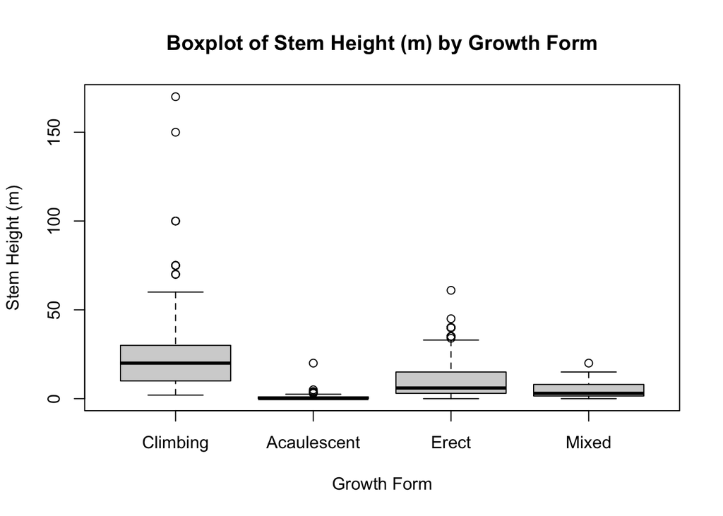

```r
boxplot(MaxStemHeight_m ~ growth_form, data = palm_clean,
    main = 'Boxplot of Stem Height (m) by Growth Form',
    xlab = 'Growth Form',
    ylab = 'Stem Height (m)')
```

3. **More pipes.** Use `%>%` to (a) keep only climbing palms, (b) select three columns and show the first 5 rows, and (c) compute the mean stem height.

```r
palm_clean |>
  filter(Climbing == 'Yes') |>
  select(SpecName, MaxStemHeight_m, AverageFruitLength_cm) |>
  mutate(mean_height = mean(MaxStemHeight_m, na.rm = TRUE)) |>
  slice_head(n = 5)
```

```
                SpecName MaxStemHeight_m AverageFruitLength_cm mean_height
1 Calamus acanthospathus              30                   2.5    25.67258
2     Calamus acuminatus              40                   0.7    25.67258
3        Calamus albidus               6                   2.5    25.67258
4     Calamus amplijugus              20                   1.0    25.67258
5    Calamus andamanicus              24                   1.8    25.67258
```

4. **Grouping by two variables.** Repeat 3.3 with `group_by(size_category, StemArmed)`.

```r
palm_clean %>%
  group_by(size_category, StemArmed) %>%
  summarize(
    n = n(),
    mean_height = mean(MaxStemHeight_m),
    sd_height = sd(MaxStemHeight_m),
    median_fruit = median(AverageFruitLength_cm)
  )
```

[output not shown]

```
# A tibble: 11 × 6
# Groups:   size_category [4]
   size_category StemArmed     n mean_height sd_height median_fruit
   <fct>         <fct>     <int>       <dbl>     <dbl>        <dbl>
 1 Small         Unarmed     764        2.30      1.58         1.25
 2 Small         Armed        64        3.32      1.57         1.6
 3 Small         <NA>          9        2.89      1.98         2
 4 Medium        Unarmed     537       10.5       3.27         1.7
 5 Medium        Armed        77        9.97      3.06         1.65
 6 Medium        <NA>          7        8.71      1.89         4.65
 7 Tall          Unarmed     316       23.0       4.39         1.8
 8 Tall          Armed        34       22.6       4.15         2
 9 Tall          <NA>          1       25        NA            1.3
10 Very Tall     Unarmed      88       49.6      22.4          1.92
11 Very Tall     Armed        10       47.5      12.5          1.55
```

5. **Base R vs. dplyr.** Reproduce your `palm_summary` means with `tapply()` or `aggregate()`. Which approach do you find easier to read?

```r
tapply(palm_clean$MaxStemHeight_m, palm_clean$size_category,
        function(x){
          return (c(mean = mean(x),
          sd = sd(x),
          median = median(x),
          max = max(x)))
        })
```

```
$Small
    mean       sd   median      max
2.382401 1.609351 2.000000 5.000000

$Medium
     mean        sd    median       max
10.395056  3.239423 10.000000 15.000000

$Tall
     mean        sd    median       max
22.996011  4.356452 20.000000 30.000000

$`Very Tall`
     mean        sd    median       max
 49.41837  21.55103  40.00000 170.00000
```

`dplyr` is easier to read compared to `tapply`.

6. **Multi-panel figure.** Use `par(mfrow = c(2, 2))` to combine your plots and a `barplot()` of size-category frequencies into one figure.

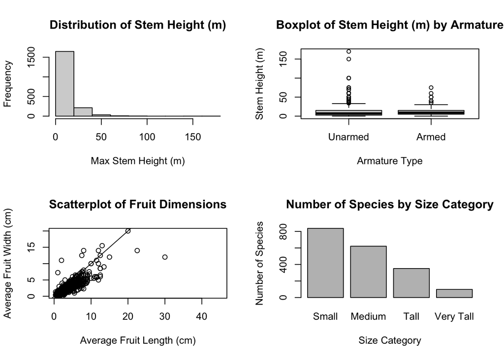

```r
par(mfrow = c(2, 2))

hist(palm_clean$MaxStemHeight_m,
     main = 'Distribution of Stem Height (m)',
     xlab = 'Max Stem Height (m)')

boxplot(MaxStemHeight_m ~ StemArmed, data = palm_clean,
    main = 'Boxplot of Stem Height (m) by Armature',
    xlab = 'Armature Type',
    ylab = 'Stem Height (m)')

plot(palm_clean$AverageFruitLength_cm, palm_clean$AverageFruitWidth_cm,
    main = 'Scatterplot of Fruit Dimensions',
    xlab = 'Average Fruit Length (cm)',
    ylab = 'Average Fruit Width (cm)')
abline(0,1)

barplot(table(palm_clean$size_category),
        main = "Number of Species by Size Category",
        xlab = "Size Category",
        ylab = "Number of Species")
```